# CTA L Ridership vs. Crime: A Station-Level Analysis 2022-2025

Author

Khulan B., Kunsh K.| GitHub: khulanb01, Kunsh1312 | Lecture: [M/W10:30 AM],[T/T/11:00 AM]

Published

March 9, 2026

## Research Question

Our primary research question is: Is there a link between CTA L monthly ridership and nearby crime? We further investigate whether this relationship varies by crime type, time and which stations show disproportionately high crime relative to ridership, and how these metrics have trended from 2022 to 2025.

Our hypothesis is that higher-ridership stations will exhibit more nearby crime due to increased foot traffic, but that this need not lower ridership. This question matters because safety perception is one of the largest barriers to CTA ridership recovery, which at one point sat at barely 60% of pre-COVID levels, and station-level analysis can inform smarter, more targeted resource allocation than citywide averages.

## Data and Approach

### Datasets

1. **CTA L Station Entries** (Chicago Data Portal): daily station-level entries for all 145 CTA L stations, 2022–2025.
2. **Chicago Crime Incidents (2001-present)** (Chicago Data Portal): containing GPS coordinates, crime type, and date for every reported incident from the Chicago Police Department, subset to 2022–2025.
3. **CTA Rail Stations Shapefiles** (`CTA_RailStations/`): point geometries for all CTA L stations, used to validate near station crime locations.
4. **CTA Rail Lines Shapefile** (`CTA_RailLines/`): line geometries for coordinates and attributes for all 8 L Lines, used to validate on train crime locations.

### Data Preprocessing and Spatial Join

We wanted to only consider crimes that could reasonably affect safety perceptions of the L trains. As such we included all crimes being labelled thought their location description as related to the L train system with a 1500 feet (approximately 450m) sanity check. To further account for the fact that crimes may not be logged as CTA crimes and that crimes near stations could still impact safety perceptions, we also included crimes that occured within 700 feet of a station (approximately 200m). We then joined these crimes to their nearest station alongside its ridership data. Merging these datasets required significant cleaning, in which **twenty-nine stations** were named differently across the ridership and shapefile datasets, so we built a mapping dictionary to reconcile them. Secondly, **Damen-Lake**, which opened in 2024, was entirely absent from the shapefile due to it being from 2023 and had to be added manually using coordinates. We also dropped a **Roosevelt/Wabash duplicate** in the shapefile as the shapefile seperates the underground and overground station while the ridership data did not. The resulting merged dataset contains one row per crime along with the station the cime is closest to and its ridership data.

### Difficulties and Limitations

The most time-consuming challenge was data cleaning. The **reconciliation between ridership and station data** was particularly difficult as both datasets at first glance due to station data having both a duplicate and missing station. As such it requred significant research and data exploration to reconcile the mismatch. Further renamings though done with AI assistance had to be carefully vetted. Beyond that, our analysis has several limitations. First, and foremost **it captures only reported crimes**, especially for crimes like pickpocketting (theft) the victim could believe that the item was lost or that the crime happened somewehere other than the L station which means that actual crime is higher. Adding on to this if there is a correlation between likelihood of crime being reported and ridership this could present a significant challenge for the validity of our findings. Further we don’t account for factors such as weather, service disruptions, or major events which could have important effects. Finally our study is in no way causal **the observed correlation does not establish causation** and while it can help inform policy it is not a silver bullet.

## Static Visualizations

### Figure 1: Top 10 Crime Types Near CTA Stations.

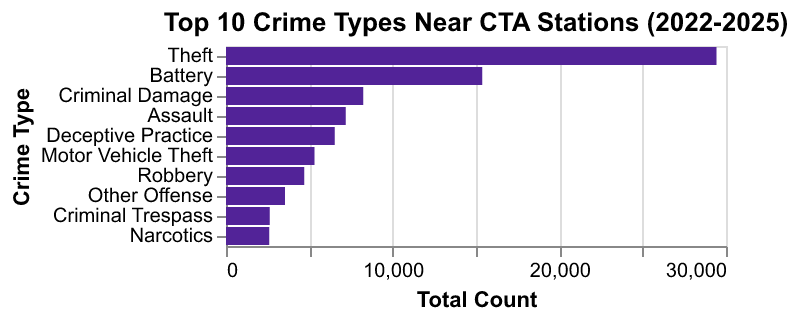

### Figure 2: Crime Heatmap.

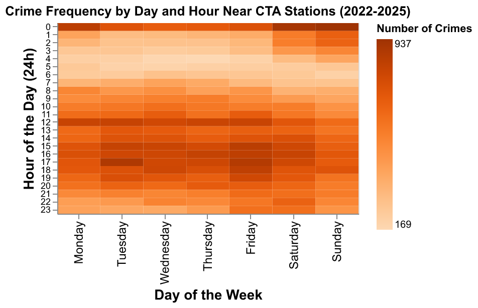

## Streamlit App

The interactive dashboard is deployed at: https://cpqbkxxgjuxwabwamt2kjq.streamlit.app/

We built an interactive Streamlit dashboard titled **“CTA Station Analysis: Crime vs. Ridership”**. **The Statistical Analysis** tab plots crime incidents per 100,000 riders against total rides with option to filter by crime type and year. We observe a negative relationship with stations that pass a certain crime rate threshold always having low ridership . This could suggest structural issues at these stations with high crime despite lower ridership. These observations also don’t vary with whether crime is violent or non violent or specific crimes suggesting that riders are somewhat agnostic in crime type when making ridership decisions so reducing specific types of crime may not help. **The Geographic Map** tab renders stations as circles on a pydeck map, with circle size driven by the user’s choice of total crimes, crimes per 100k riders, or total riders, making spatial hotspots immediately visible. Here we clearly see transit hubs and downtown tned to have both the higest ridership and crime incidents. However for crime rate these tend to be on the outskirts both south like King Drive and north like Berwyn.